# Relationship between Women’s Education and Fertility Rates (2015)

Data Analysis Report

2025-05-16

## 1. Data Preparation

The analysis uses data from 2015, comparing women’s educational attainment (as a percentage of men’s education) with fertility rates across different countries.

## 2. Global Patterns

### Women’s Education Ratio (% of Men’s Education)

The following map shows the ratio of women’s educational attainment compared to men’s education levels for ages 25-34 years across different countries. Higher percentages (lighter colors) indicate greater educational equality between women and men.

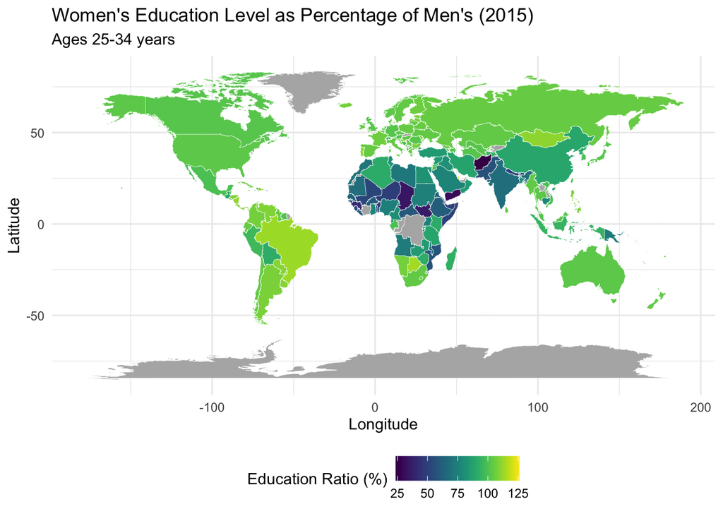

### Fertility Rate

The map below displays fertility rates (children per woman) across different countries. Lighter colors indicate higher fertility rates.

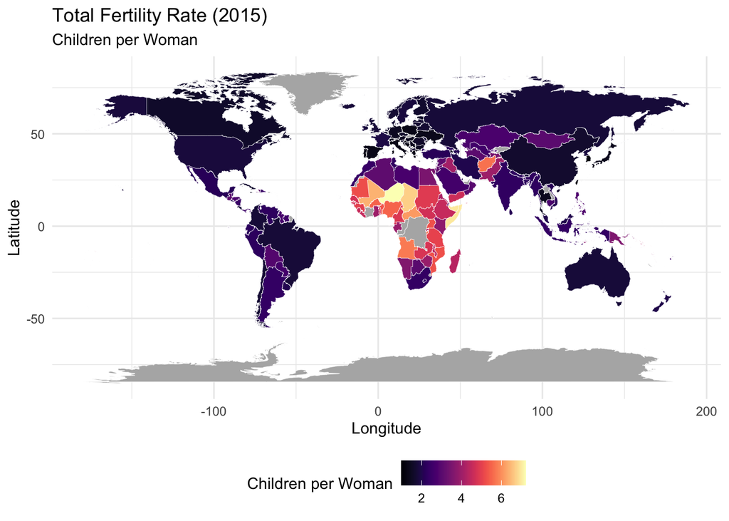

## 3. Relationship Analysis

The following scatter plot examines the relationship between women’s education levels and fertility rates:

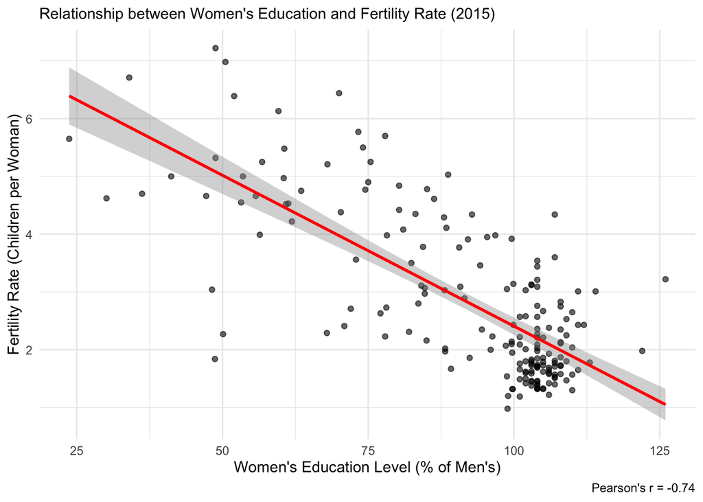

## 4. Interpretation

The scatterplot and correlation analysis reveal a strong negative correlation (r = -0.74) between women’s education levels (as a percentage of men’s) and fertility rates in 2015. This suggests that countries where women’s education levels are closer to men’s tend to have lower fertility rates. This relationship aligns with global development patterns, where increased educational opportunities for women are often associated with lower fertility rates, likely due to factors such as increased access to family planning, career opportunities, and delayed childbearing.

## 5. My Reflection about Using AI for Data Analysis

The process was surprisingly easy. However, I noticed two interesting points:

- when cursor checked the data it selected 2015 data, the last complete year for educational parity, even though I asked it to select 2022. If I was not watching this carefully I might have missed that cursor chose to select a different year than I asked.
- cursor incorrectly interpreted the maps, stating in both maps that the darker colours were the higher values - it was actually the other way around. My main reflection is that it is important to carefully review the output from cursor and check all the outputs carefully.